POLS 7012 Midterm

Elise Blasingame

October 28, 2020

### Problem 1

$$U(x)=\sqrt{1-x}+\sqrt{\frac{x}{W}}$$
First, we need to take the derivative of this function.

$$\frac{d}{dx}U(x)=\frac{d}{dx}(\sqrt{1-x})+\frac{d}{dx}(\sqrt{\frac{x}{W}})$$
$$\frac{d}{dx}U(x)=\frac{d}{dx}[(1-x)^\frac{1}{2}]+\frac{d}{dx}[({\frac{x}{W}})^\frac{1}{2}]$$
We can multiply each function’s derivative by the derivative of the value inside the parenthesis:
$$\frac{d}{dx}U(x)=(-1)[\frac{1}{2}(1-x)^\frac{-1}{2}]+\frac{1}{2W}(\frac{x}{W})^\frac{-1}{2}$$

Now, we need to set the derivative equal to zero, and solve for x.
$$0=(-1)[\frac{1}{2}(1-x)^\frac{-1}{2}]+\frac{1}{2W}(\frac{x}{W})^\frac{-1}{2}$$
$$0=\frac{1}{\sqrt{1-x}}+\frac{1}{\sqrt\frac xW}$$
$${\sqrt{1-x}}=W{\sqrt\frac xW}$$
$${1-x}=Wx$$
$$x=\frac{1}{1+W}$$
This is the fraction that represents the tax revenue he should devote to private goods to maximize his winning coalition.

Based on this, we can say that as the winning coalition grows, the amount of revenue he should devote to private goods decreases.

### Problem 2

```r
library(tidyverse)
```

##### Step 1: Load the FIW data into R.

```r
FIW <- read.csv(file = 'data/2020_All_Data_FIW_2013-2020.csv', skip = 1)
head(FIW)
```

```
##   Country.Territory  Region C.T Edition Status PR.rating CL.rating A1 A2 A3  A
## 1          Abkhazia Eurasia   t    2020     PF         5         5  2  2  1  5
## 2       Afghanistan    Asia   c    2020     NF         5         6  1  1  1  3
## 3           Albania  Europe   c    2020     PF         3         3  3  3  2  8
## 4           Algeria    MENA   c    2020     NF         6         5  1  1  1  3
## 5           Andorra  Europe   c    2020      F         1         1  4  4  4 12
## 6            Angola     SSA   c    2020     NF         6         5  0  2  1  3
##   B1 B2 B3 B4  B C1 C2 C3  C Add.Q Add.A PR D1 D2 D3 D4  D E1 E2 E3  E F1 F2 F3
## 1  2  3  2  1  8  1  1  2  4     0   N/A 17  2  2  1  3  8  3  2  1  6  1  1  1
## 2  2  2  1  2  7  1  1  1  3     0   N/A 13  2  1  1  2  6  2  1  1  4  1  0  0
## 3  3  3  3  3 12  3  2  2  7     0   N/A 27  2  4  3  4 13  4  3  2  9  2  2  2
## 4  1  1  1  1  4  1  1  1  3     0   N/A 10  1  1  2  3  7  2  1  1  4  1  1  2
## 5  4  4  4  3 15  4  4  4 12     0   N/A 39  3  3  4  4 14  4  4  3 11  4  4  4
## 6  2  1  1  2  6  1  1  0  2     0   N/A 11  1  2  2  2  7  2  2  2  6  1  1  1
##   F4  F G1 G2 G3 G4  G CL Total
## 1  1  4  1  1  2  1  5 23    40
## 2  1  2  0  1  0  1  2 14    27
## 3  3  9  3  2  2  2  9 40    67
## 4  2  6  2  2  2  1  7 24    34
## 5  3 15  4  4  3  4 15 55    94
## 6  2  5  1  1  1  0  3 21    32
```

##### Step 2: Keep only the most recent year of data. Keep only the countries (not the territories).

```r
#library(dplyr)


FIW2020 <- filter(FIW, Edition == '2020') #Filter for 2020 data only


FIW2020 %>%
  select(Country.Territory, C.T, Edition, A, B, C, D, E, F, G) %>% # select relevant variables
  filter(C.T == "c") %>%
  head(10) # output the first 10 rows
```

```
##      Country.Territory C.T Edition  A  B  C  D  E  F  G
## 1          Afghanistan   c    2020  3  7  3  6  4  2  2
## 2              Albania   c    2020  8 12  7 13  9  9  9
## 3              Algeria   c    2020  3  4  3  7  4  6  7
## 4              Andorra   c    2020 12 15 12 14 11 15 15
## 5               Angola   c    2020  3  6  2  7  6  5  3
## 6  Antigua and Barbuda   c    2020 12 13  8 15 10 14 13
## 7            Argentina   c    2020 11 16  8 15 11 10 14
## 8              Armenia   c    2020  6 10  5  9  8  6  9
## 9            Australia   c    2020 12 16 12 15 12 15 15
## 10             Austria   c    2020 12 15 10 14 12 15 15
```

##### Step 3: Of the 25 questions, some are about democracy (i.e. are political leaders elected?) and others are about freedom/liberty (i.e. can people practice their religion without fear of persecution? is there a free and independent media? etc.). Create one variable called democracy_score, equal to the sum of all the scores on questions related to democracy, and another variable called liberty_score, equal to the sum of all the scores on questions related to liberty.

```r
FIW2020 <- FIW2020 %>% #create democracy_score
  mutate(democracy_score = A + B + C)

summary(FIW2020$democracy_score)
```

```
##    Min. 1st Qu.  Median    Mean 3rd Qu.    Max.
##    0.00   10.25   25.00   22.48   35.00   40.00
```

```r
FIW2020 <- FIW2020 %>% #create liberty_score
  mutate(liberty_score = D + E + F + G)

summary(FIW2020$liberty_score)
```

```
##    Min. 1st Qu.  Median    Mean 3rd Qu.    Max.
##    1.00   20.00   35.00   34.41   51.75   60.00
```

##### Step 4: Visualize the relationship between liberty and democracy.

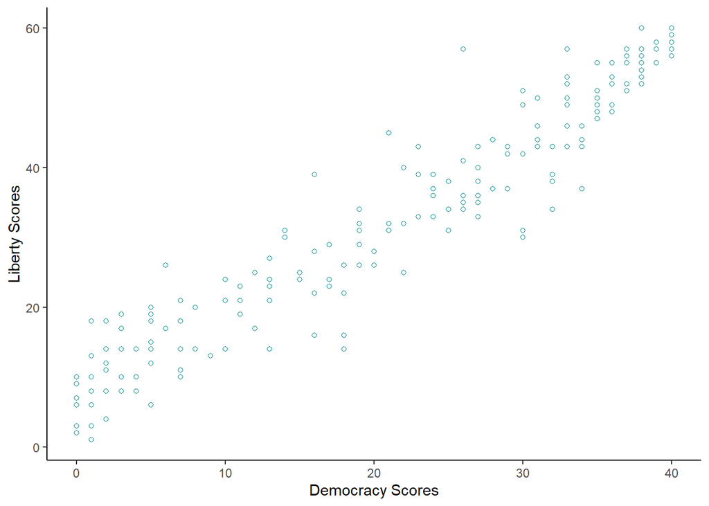

```r
ggplot(FIW2020, aes(x=democracy_score, y=liberty_score)) +
  geom_point(color = 'darkcyan', shape=1)+
  theme_classic() +
  labs(x = 'Democracy Scores',
       y = 'Liberty Scores')
```

##### Step 5: Split the countries into democratic and non-democratic (your choice where you split) and conduct a bivariate hypothesis test. Are the democratic countries more free on average than the non-democratic countries?

ENB: I am setting the democracy cut-off at countries with scores of =/>21

```r
FIW2020 <- FIW2020 %>%
  mutate(democracy_status = case_when(democracy_score < 21  ~ 'NonDemocratic', TRUE ~ 'Democratic'))


test1 <- FIW2020 %>%
  filter(democracy_status %in% c('NonDemocratic', 'Democratic')) %>%
  t.test(liberty_score ~ democracy_status, data = .)


test1
```

```
##
##  Welch Two Sample t-test
##
## data:  liberty_score by democracy_status
## t = 24.775, df = 197.46, p-value < 2.2e-16
## alternative hypothesis: true difference in means is not equal to 0
## 95 percent confidence interval:
##  27.63798 32.41829
## sample estimates:
##    mean in group Democratic mean in group NonDemocratic
##                    47.14050                    17.11236
```

##### Because the p-value is very low, we can reject the null hypothesis and conclude that Democratic Countries are typically ‘more free’ than Non-Democratic Countries.